# K=7 Spatial Tissue Niche Characterization

Rendered 261017235502 from frozen K=7 inputs.

**Interpretation boundary:** composition-derived factors are not automatically validated biological niches. This analysis is disease-blind and did not rerun RCTD, NMF, edgeR, GSEA, or disease tests.

## Reproducibility summary

| family_label | patient_n | structured_patient_n | structured_patient_fraction | median_largest_component_fraction | median_component_n | median_abs_usage_nUMI_spearman | median_abs_usage_nGene_spearman | median_patient_composition_correlation | median_expected_marker_delta_log2cpm | expected_marker_positive_patient_fraction | median_loading_hotspot_cosine_x | minimum_loading_hotspot_cosine_x | median_loading_hotspot_cosine_y | minimum_loading_hotspot_cosine_y | median_loading_hotspot_cosine | minimum_loading_hotspot_cosine |
| --- | --- | --- | --- | --- | --- | --- | --- | --- | --- | --- | --- | --- | --- | --- | --- | --- |
| LEC-associated | 21 | 1 | 0.04762 | 0.07438 | 92 | 0.03585 | 0.03674 | 0.8887 | -0.02785 | 0.2381 | 0.6367 | 0.5311 | 0.6367 | 0.5311 | 0.6367 | 0.5311 |
| Blood-endothelial | 21 | 1 | 0.04762 | 0.08382 | 89 | 0.07429 | 0.07295 | 0.8552 | -0.1504 | 0.1905 | 0.542 | 0.382 | 0.542 | 0.382 | 0.542 | 0.382 |
| AT1-associated | 21 | 2 | 0.09524 | 0.0795 | 99 | 0.132 | 0.1328 | 0.9154 | -0.1524 | 0.3333 | 0.7929 | 0.3962 | 0.7929 | 0.3962 | 0.7929 | 0.3962 |
| Perivascular-stromal | 21 | 3 | 0.1429 | 0.09836 | 84 | 0.1469 | 0.1483 | 0.8896 | -0.06593 | 0.09524 | 0.5058 | 0.3528 | 0.5058 | 0.3528 | 0.5058 | 0.3528 |
| B-enriched/mixed-immune | 21 | 4 | 0.1905 | 0.08425 | 104 | 0.1234 | 0.122 | 0.9003 | -0.0325 | 0.3333 | 0.7274 | 0.6157 | 0.7274 | 0.6157 | 0.7274 | 0.6157 |
| Ciliated-associated | 21 | 3 | 0.1429 | 0.1194 | 77 | 0.1006 | 0.09787 | 0.8395 | -0.05928 | 0.3333 | 0.4927 | 0.2125 | 0.4927 | 0.2125 | 0.4927 | 0.2125 |
| Fibroblast-associated | 21 | 3 | 0.1429 | 0.1212 | 80 | 0.1175 | 0.1173 | 0.8977 | -0.04877 | 0.3333 | 0.5417 | 0.3669 | 0.5417 | 0.3669 | 0.5417 | 0.3669 |

## Candidate classification

| family_label | classification | rationale | disease_specificity_claim | independent_validation_status |
| --- | --- | --- | --- | --- |
| LEC-associated | D. Unresolved / technically confounded | limited recurrence, fragmentation, or technical association | not tested in this disease-blind characterization | not independently validated; composition is model-derived |
| Blood-endothelial | D. Unresolved / technically confounded | limited recurrence, fragmentation, or technical association | not tested in this disease-blind characterization | not independently validated; composition is model-derived |
| AT1-associated | D. Unresolved / technically confounded | limited recurrence, fragmentation, or technical association | not tested in this disease-blind characterization | not independently validated; composition is model-derived |
| Perivascular-stromal | C. Patient-specific candidate | coherent connected structure in a subset of patients | not tested in this disease-blind characterization | not independently validated; composition is model-derived |
| B-enriched/mixed-immune | C. Patient-specific candidate | coherent connected structure in a subset of patients | not tested in this disease-blind characterization | not independently validated; composition is model-derived |
| Ciliated-associated | C. Patient-specific candidate | coherent connected structure in a subset of patients | not tested in this disease-blind characterization | not independently validated; composition is model-derived |
| Fibroblast-associated | C. Patient-specific candidate | coherent connected structure in a subset of patients | not tested in this disease-blind characterization | not independently validated; composition is model-derived |

## Input and factor-map audit

| record_type | chip | family_label | chip_specific_factor | patient_n | bin_n | top_state_1 | top_loading_1 | top_state_2 | top_loading_2 | top_state_3 | top_loading_3 | loading_sha256 | input_name | path | sha256 |
| --- | --- | --- | --- | --- | --- | --- | --- | --- | --- | --- | --- | --- | --- | --- | --- |
| factor_map | K8 | LEC-associated | F01 | 7.0 | 27445.0 | Lymphatic endothelial | 0.773657 | Fibroblast | 0.153133 | Myofibroblast | 0.030574 | e2083e4d5ce2674f327f1d6ad33701dea76fdeeb66956c6d5d4a8658d325abc5 | NaN | NaN | NaN |
| factor_map | J2 | LEC-associated | F03 | 7.0 | 58772.0 | Lymphatic endothelial | 0.853563 | AT2/alveolar transitional | 0.040704 | NK | 0.018001 | 742cd81c9b5bd86308227d043242db52cc06f89735411e6fee522e6a58c8ed06 | NaN | NaN | NaN |
| factor_map | L3 | LEC-associated | F02 | 7.0 | 39982.0 | Lymphatic endothelial | 0.816935 | AT2/alveolar transitional | 0.034513 | NK | 0.026944 | 9609a0c5f84ace3345a07b688ae9eba8eb4c399222dc49ff8cd0f4efbe1da1a9 | NaN | NaN | NaN |
| factor_map | K8 | Blood-endothelial | F02 | 7.0 | 27445.0 | Blood endothelial | 0.747651 | T | 0.045459 | Mast/Basophil | 0.040987 | e2083e4d5ce2674f327f1d6ad33701dea76fdeeb66956c6d5d4a8658d325abc5 | NaN | NaN | NaN |
| factor_map | J2 | Blood-endothelial | F04 | 7.0 | 58772.0 | Blood endothelial | 0.609303 | AT2/alveolar transitional | 0.104555 | Basal-like epithelial | 0.059657 | 742cd81c9b5bd86308227d043242db52cc06f89735411e6fee522e6a58c8ed06 | NaN | NaN | NaN |
| factor_map | L3 | Blood-endothelial | F07 | 7.0 | 39982.0 | Blood endothelial | 0.402745 | T | 0.121849 | Basal-like epithelial | 0.094887 | 9609a0c5f84ace3345a07b688ae9eba8eb4c399222dc49ff8cd0f4efbe1da1a9 | NaN | NaN | NaN |
| factor_map | K8 | AT1-associated | F03 | 7.0 | 27445.0 | AT1 | 0.740332 | T | 0.071643 | NK | 0.056932 | e2083e4d5ce2674f327f1d6ad33701dea76fdeeb66956c6d5d4a8658d325abc5 | NaN | NaN | NaN |
| factor_map | J2 | AT1-associated | F01 | 7.0 | 58772.0 | AT1 | 0.802639 | Perivascular/mesothelial stromal | 0.056068 | Blood endothelial | 0.028092 | 742cd81c9b5bd86308227d043242db52cc06f89735411e6fee522e6a58c8ed06 | NaN | NaN | NaN |
| factor_map | L3 | AT1-associated | F03 | 7.0 | 39982.0 | AT1 | 0.932582 | Myofibroblast | 0.017625 | Dendritic cell | 0.013813 | 9609a0c5f84ace3345a07b688ae9eba8eb4c399222dc49ff8cd0f4efbe1da1a9 | NaN | NaN | NaN |
| factor_map | K8 | Perivascular-stromal | F04 | 7.0 | 27445.0 | Perivascular/mesothelial stromal | 0.611583 | B | 0.084191 | Fibroblast | 0.076892 | e2083e4d5ce2674f327f1d6ad33701dea76fdeeb66956c6d5d4a8658d325abc5 | NaN | NaN | NaN |
| factor_map | J2 | Perivascular-stromal | F07 | 7.0 | 58772.0 | Perivascular/mesothelial stromal | 0.438455 | Basal-like epithelial | 0.142433 | T | 0.084092 | 742cd81c9b5bd86308227d043242db52cc06f89735411e6fee522e6a58c8ed06 | NaN | NaN | NaN |
| factor_map | L3 | Perivascular-stromal | F05 | 7.0 | 39982.0 | Perivascular/mesothelial stromal | 0.695401 | Mast/Basophil | 0.076073 | AT2/alveolar transitional | 0.056946 | 9609a0c5f84ace3345a07b688ae9eba8eb4c399222dc49ff8cd0f4efbe1da1a9 | NaN | NaN | NaN |
| factor_map | K8 | B-enriched/mixed-immune | F05 | 7.0 | 27445.0 | B | 0.679996 | Ciliated epithelial | 0.089821 | Blood endothelial | 0.079062 | e2083e4d5ce2674f327f1d6ad33701dea76fdeeb66956c6d5d4a8658d325abc5 | NaN | NaN | NaN |
| factor_map | J2 | B-enriched/mixed-immune | F02 | 7.0 | 58772.0 | B | 0.676934 | Ciliated epithelial | 0.111447 | AT1 | 0.110566 | 742cd81c9b5bd86308227d043242db52cc06f89735411e6fee522e6a58c8ed06 | NaN | NaN | NaN |
| factor_map | L3 | B-enriched/mixed-immune | F01 | 7.0 | 39982.0 | B | 0.710053 | Blood endothelial | 0.067780 | Fibroblast | 0.060647 | 9609a0c5f84ace3345a07b688ae9eba8eb4c399222dc49ff8cd0f4efbe1da1a9 | NaN | NaN | NaN |
| factor_map | K8 | Ciliated-associated | F06 | 7.0 | 27445.0 | Ciliated epithelial | 0.477360 | NK | 0.136821 | Basal-like epithelial | 0.078650 | e2083e4d5ce2674f327f1d6ad33701dea76fdeeb66956c6d5d4a8658d325abc5 | NaN | NaN | NaN |
| factor_map | J2 | Ciliated-associated | F06 | 7.0 | 58772.0 | Ciliated epithelial | 0.529735 | T | 0.104711 | NK | 0.083206 | 742cd81c9b5bd86308227d043242db52cc06f89735411e6fee522e6a58c8ed06 | NaN | NaN | NaN |
| factor_map | L3 | Ciliated-associated | F04 | 7.0 | 39982.0 | Ciliated epithelial | 0.627548 | T | 0.129257 | NK | 0.078319 | 9609a0c5f84ace3345a07b688ae9eba8eb4c399222dc49ff8cd0f4efbe1da1a9 | NaN | NaN | NaN |
| factor_map | K8 | Fibroblast-associated | F07 | 7.0 | 27445.0 | Fibroblast | 0.637177 | AT1 | 0.153692 | Perivascular/mesothelial stromal | 0.070467 | e2083e4d5ce2674f327f1d6ad33701dea76fdeeb66956c6d5d4a8658d325abc5 | NaN | NaN | NaN |
| factor_map | J2 | Fibroblast-associated | F05 | 7.0 | 58772.0 | Fibroblast | 0.706851 | AT2/alveolar transitional | 0.105830 | Mast/Basophil | 0.050562 | 742cd81c9b5bd86308227d043242db52cc06f89735411e6fee522e6a58c8ed06 | NaN | NaN | NaN |
| factor_map | L3 | Fibroblast-associated | F06 | 7.0 | 39982.0 | Fibroblast | 0.563940 | Mast/Basophil | 0.153743 | T | 0.082185 | 9609a0c5f84ace3345a07b688ae9eba8eb4c399222dc49ff8cd0f4efbe1da1a9 | NaN | NaN | NaN |
| input | NaN | NaN | NaN | NaN | NaN | NaN | NaN | NaN | NaN | NaN | NaN | NaN | spatial_metadata | D:\Lung ST\codex agent\stereo_seq\stereo_seq\results\reanalysis\ALL21_SHARED_UNBIASED_DISCRETE_NICHE_ATLAS_20261011_191652_attempt4\02_ALL21_SHARED_NICHE_ASSIGNMENTS.tsv.gz | cbd1873c79175818d99054d6f6794e1d9d50a0fd02216ad7d4fe4a573b56d3a8 |
| input | NaN | NaN | NaN | NaN | NaN | NaN | NaN | NaN | NaN | NaN | NaN | NaN | reference18_neighborhood_assay | D:\Lung ST\codex agent\stereo_seq\stereo_seq\results\reanalysis\ALL21_SHARED_UNBIASED_DISCRETE_NICHE_ATLAS_20261011_191652_attempt4\12_SHARED_NICHE_ASSAY.h5 | 6a8c1d18412478a8e89ba898d0dc48030d5c5c7b6d93515797d32f92f7f3306f |
| input | NaN | NaN | NaN | NaN | NaN | NaN | NaN | NaN | NaN | NaN | NaN | NaN | raw_counts | D:\Lung ST\codex agent\stereo_seq\stereo_seq\results\reanalysis\RCTD_SIX_DATASET_LEVEL1_ALL21_20260916_223802\prepared_inputs\six_dataset_level1_rctd_inputs.h5 | 0ca7d516402b8c1e41eaabeaa3b02811bfffce13451ea5cab7c17638a47d84f9 |
| input | NaN | NaN | NaN | NaN | NaN | NaN | NaN | NaN | NaN | NaN | NaN | NaN | family_map | D:\Lung ST\codex agent\stereo_seq\stereo_seq\results\reanalysis\REFERENCE18_NEIGHBORHOOD_NMF_K7_STATE_SENSITIVITY_20261016_210302_attempt5\07_CROSS_CHIP_FAMILY_MAP.tsv | 26135d067918f0f699697ca2bc20216b6cceae26e3bd279f5d750d683ebb6d94 |

## Validation

| check | expected | observed | passed |
| --- | --- | --- | --- |
| patient_n | 21 | 21 | True |
| family_n | 7 | 7 | True |
| chip_n | 3 | 3 | True |
| threshold_n | 3 | 3 | True |
| patient_family_threshold_n | 441 | 441 | True |
| relationship_patient_pair_band_n | 1323 | 1323 | True |
| classification_n | 7 | 7 | True |
| atlas_pdf_exists | True | True | True |
| atlas_pdf_nonempty | True | True | True |
| patient_continuous_png_n | 21 | 21 | True |
| patient_hotspot_png_n | 21 | 21 | True |
| summary_png_n | 6 | 6 | True |
| methods_report_exists | True | True | True |
| next_steps_exists | True | True | True |

## Summary figures

### Summary Factor Marker Support

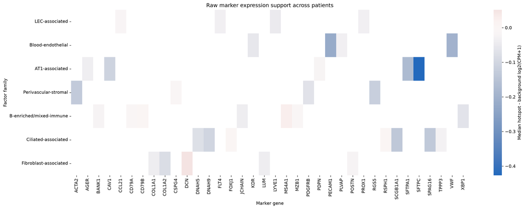

### Summary Factor Reference18 Composition

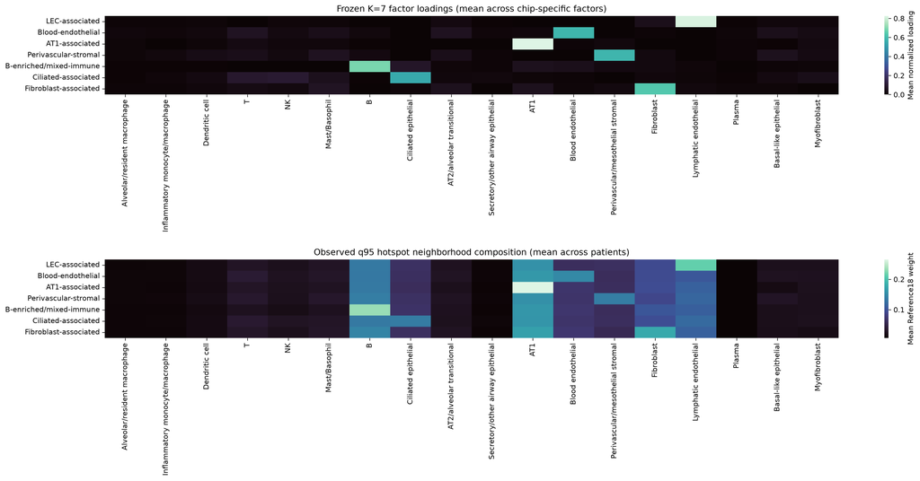

### Summary Factor Reproducibility

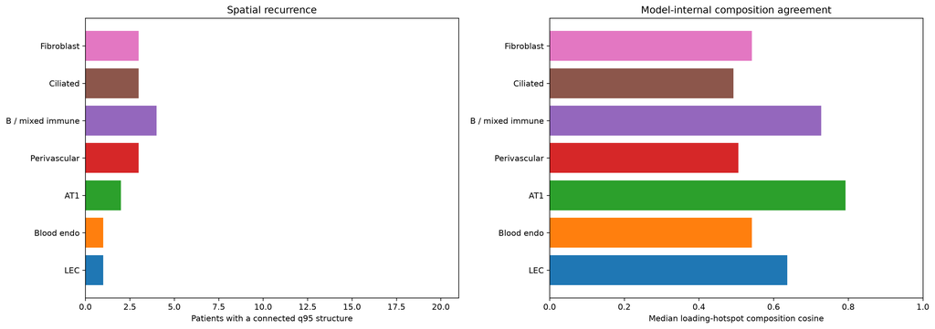

### Summary Factor Spatial Relationships

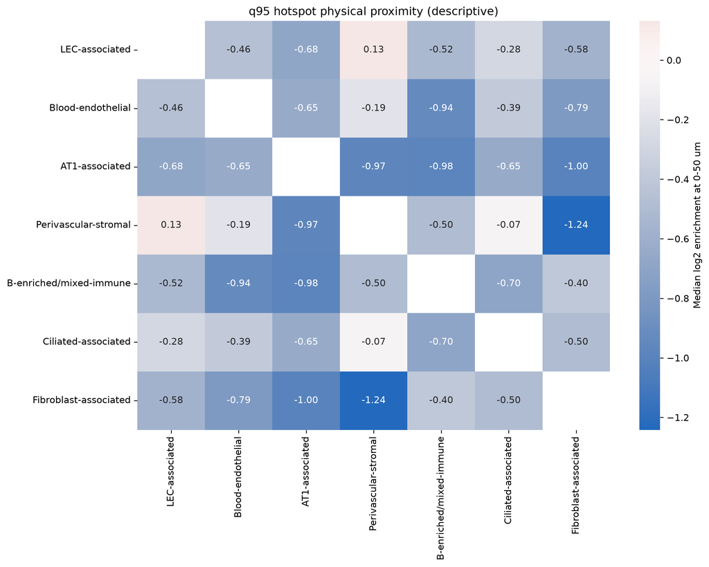

### Summary Representative Connected Hotspots

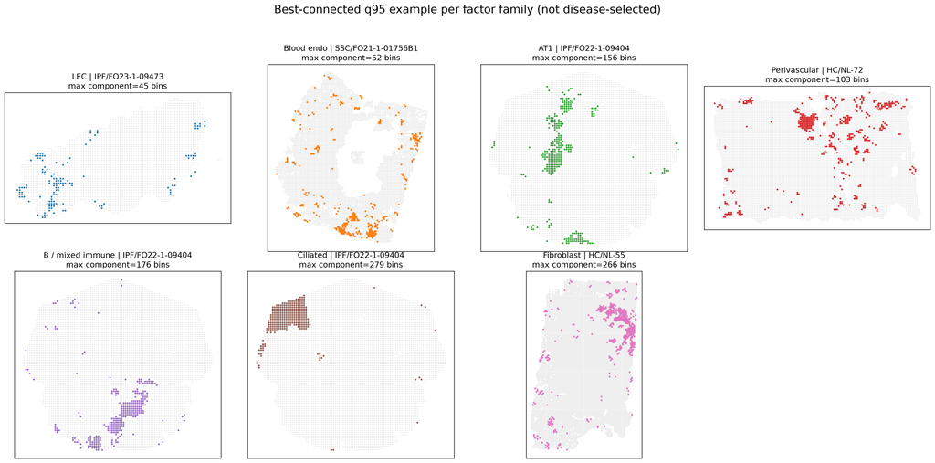

### Summary Representative Patient Tissue Atlas

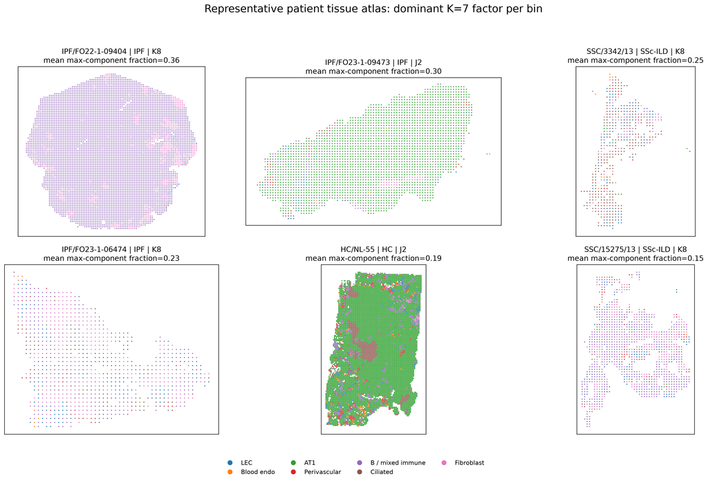

## Methods and findings (Chinese)

# K=7 空间组织生态位表征：方法与发现

## 分析边界

本轮完全复用冻结的 K=7 NMF factor、relative usage、跨芯片 family map、Reference18 neighborhood composition、原始 Bin50 counts 以及既有 edgeR/GSEA。未重新运行 RCTD、NMF、edgeR 或 GSEA，也未进行新的疾病差异检验。

方法框架参考 Mayr et al. (2024) 对去卷积细胞组成、NMF niche 与空间邻接的分层解释，但本项目保持自身的 Bin50、Reference18 和逐芯片 factor 定义；composition-derived factor 不被自动当作经过组织学验证的 niche。论文：https://pmc.ncbi.nlm.nih.gov/articles/PMC11313858/

## 空间定义

- 连续图使用每位患者内部的直接 K=7 relative usage；跨芯片色标不共享。
- q90/q95/q99 使用患者内精确 top 10%/5%/1% 排名，避免大量并列值扩大热点。
- 邻接为同患者 25 μm 网格的四/八邻域；不跨患者连边。组织不相连片段由全组织图自动区分。
- 连通组件面积按每个 Bin50 为 625 μm²；紧凑度为 4πA/P²；边缘比例以全组织八邻域不足 8 个定义。
- 0-50、50-100、100-200 μm 关系为描述性 pair enrichment；同时单列同位置 hotspot overlap，避免把混合 usage 当作物理邻近。

## 核心结果

- **LEC-associated**：q95 形成预设连通结构的患者 1/21；最大连通块占比中位数 0.074；热点组成与对应 loading 的 cosine 中位数 0.637；预期 marker 的患者阳性比例 0.24。分类：D. Unresolved / technically confounded。
- **Blood-endothelial**：q95 形成预设连通结构的患者 1/21；最大连通块占比中位数 0.084；热点组成与对应 loading 的 cosine 中位数 0.542；预期 marker 的患者阳性比例 0.19。分类：D. Unresolved / technically confounded。
- **AT1-associated**：q95 形成预设连通结构的患者 2/21；最大连通块占比中位数 0.079；热点组成与对应 loading 的 cosine 中位数 0.793；预期 marker 的患者阳性比例 0.33。分类：D. Unresolved / technically confounded。
- **Perivascular-stromal**：q95 形成预设连通结构的患者 3/21；最大连通块占比中位数 0.098；热点组成与对应 loading 的 cosine 中位数 0.506；预期 marker 的患者阳性比例 0.10。分类：C. Patient-specific candidate。
- **B-enriched/mixed-immune**：q95 形成预设连通结构的患者 4/21；最大连通块占比中位数 0.084；热点组成与对应 loading 的 cosine 中位数 0.727；预期 marker 的患者阳性比例 0.33。分类：C. Patient-specific candidate。
- **Ciliated-associated**：q95 形成预设连通结构的患者 3/21；最大连通块占比中位数 0.119；热点组成与对应 loading 的 cosine 中位数 0.493；预期 marker 的患者阳性比例 0.33。分类：C. Patient-specific candidate。
- **Fibroblast-associated**：q95 形成预设连通结构的患者 3/21；最大连通块占比中位数 0.121；热点组成与对应 loading 的 cosine 中位数 0.542；预期 marker 的患者阳性比例 0.33。分类：C. Patient-specific candidate。

## 解释限制

Reference18 composition 与 NMF loading 的一致性属于模型内部解释，不是独立验证。marker 支持来自原始计数的描述性定位，但仍可能反映细胞组成和测序深度。50 μm center-excluded neighborhood 输入本身会产生空间平滑，因此只有重复出现、具有连通形态且有原始表达支持的结构才进入候选 niche；本轮结果不支持直接命名 TLS、fibrotic niche 或疾病特异性 niche。

# 下一步建议

1. 优先对 C 类结构逐患者叠加 ssDNA/组织学图像复核边界；当前最值得看的是 B-mixed、Ciliated、Fibroblast 与 Perivascular 在少数患者中的大连通块。

2. 对候选区域进行独立的原位 marker 验证；组成因子与 Reference18 的一致性不能替代验证。

3. 在组织结构冻结之前，不新增疾病显著性检验，也不根据疾病结果调整 q90/q95/q99。

4. q99 仅用于极高 usage 核心；若热点少于 20 个 Bin50 或高度孤立，不将其视为完整 niche。

5. 后续疾病比较必须以患者为重复并分层审计芯片异质性；这将在本任务完成后恢复上一项 joint vs chip-stratified edgeR/GSEA 工作。

## 需要优先人工复核的空间关系（q95，0-50 μm，中位 log2 enrichment）

- LEC-associated ↔ Perivascular-stromal: 0.132
- Perivascular-stromal ↔ Ciliated-associated: -0.067
- Blood-endothelial ↔ Perivascular-stromal: -0.189
- LEC-associated ↔ Ciliated-associated: -0.283
- Blood-endothelial ↔ Ciliated-associated: -0.386

这些关系仅表示共定位/邻近，不表示细胞通讯或因果作用。

## 与 SSc-ILD 研究的关系

免疫-血管、成纤维-周血管以及上皮结构可能具有后续 SSc-ILD 研究价值，但本轮是疾病盲法表征，尚未证明任何结构具有 SSc-ILD 特异性。

## Reproducible commands

```
powershell.exe -NoProfile -ExecutionPolicy Bypass -File WORK/run_k7_spatial_tissue_niche_characterization.ps1
powershell.exe -NoProfile -ExecutionPolicy Bypass -File WORK/run_k7_spatial_tissue_niche_render.ps1
envs/stereo_seq_py/Scripts/python.exe scripts/1165_render_k7_spatial_tissue_niche_report.py --analysis-dir results/reanalysis/K7_SPATIAL_TISSUE_NICHE_CHARACTERIZATION
```

## Session information

```
Python 3.12.14 | pandas 3.0.5 | numpy 2.4.6 | matplotlib 3.11.1 | seaborn 0.13.2
```